# Coursera Statistical Inference Project

Josh Starkey

January 31, 2016

### Overview

This is a Coursera project for the Data Science Specialization: Statisical Inference Course. The project is described https://www.coursera.org/learn/statistical-inference/peer/3k8j5/statistical-inference-course-project. This project has two parts. The first part investigates the exponential distribution in R and compares it with the Central Limit Theorem. The second part performs some basic analysis on the ToothGrowth data provided by R. This report is uploaded as a pdf, but the R Markdown is located https://github.com/star9475/StatInferenceProject/blob/master/StatInfProject.Rmd.

First, let’s load libraries:

```r
library(ggplot2)
```

### Part 1

#### Simulations

Let’s run a simulation of an exponential distribution with lambda = .2.

The expected mean of the distribution is 1/lambda.

```r
expmean <- 1 / .2
```

```
## [1] 5
```

```r
expvar <- ((1 / .2)^2)
```

```
## [1] 25
```

The number of simulations for the experiment is 1000.  
The number of samples is 40.

```r
nosim <- 1000
nosample <- 40
```

Let’s perform 1000 simulations of the exponential distribution, and take 40 samples of each simulation. We’ll set the seed for reproducability.

```r
set.seed(1623);
meandata <- data.frame(
     x = c(apply(matrix(rexp(nosim * nosample, .2), nosim), 1, mean)),
     n = factor(rep(c(nosample), c(nosample)))
     )
```

Let’s perform the same simulation: 1000 simulations of the exponential distribution. This time we’ll calculate the variance of the samples. We’ll set the seed for reproducability.

```r
set.seed(1623);
vardata <- data.frame(
     x = c(apply(matrix(rexp(nosim * nosample, .2), nosim), 1, var)),
     n = factor(rep(c(nosample), c(nosample)))
     )
```

#### Sample Mean versus Theoretical Mean

We plot the distribution of sample means. The red line represents the expected mean `expmean = 5`, and the green line represents the sample mean`sampmean = mean(meandata[,1])=5.011907`. They are very close.

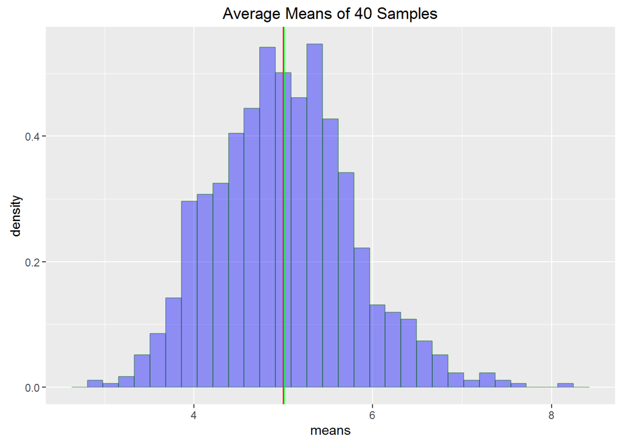

#### Sample Variance versus Theoretical Variance

We plot the distribution of sample variances. The red line represents the expected variance `expvar = 25`, and the green line represents the sample variance`sampvar = mean(vardata[,1])=24.91826`. They are very close.

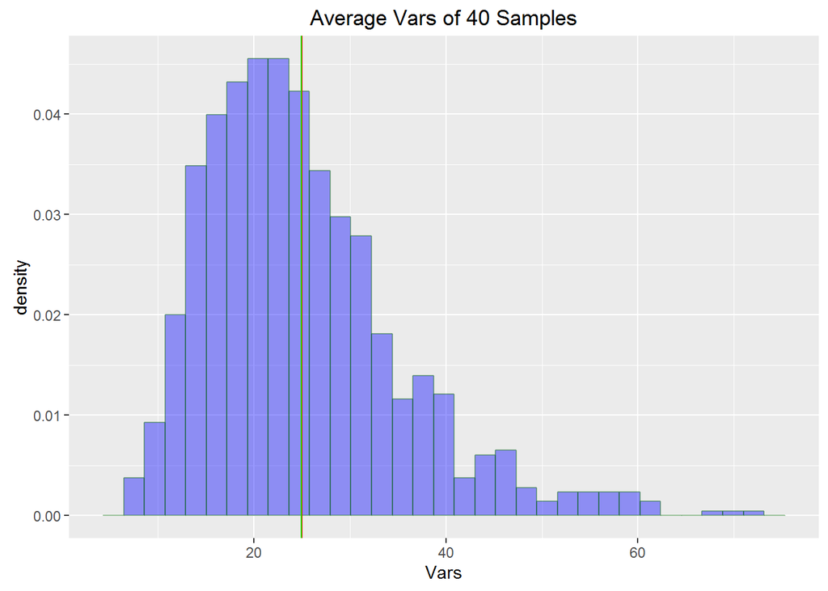

#### Distribution

The Central Limit Theorm states that averages are approximately normal with distributions centered at the population mean, which we have shown in the first figure “Average Means of 40 samples”.

### Part 2

#### Load the ToothGrowth data and perform some basic exploratory data analyses

```r
data("ToothGrowth")

head(ToothGrowth)
```

```
##    len supp dose
## 1  4.2   VC  0.5
## 2 11.5   VC  0.5
## 3  7.3   VC  0.5
## 4  5.8   VC  0.5
## 5  6.4   VC  0.5
## 6 10.0   VC  0.5
```

```r
str(ToothGrowth)
```

```
## 'data.frame':    60 obs. of  3 variables:
##  $ len : num  4.2 11.5 7.3 5.8 6.4 10 11.2 11.2 5.2 7 ...
##  $ supp: Factor w/ 2 levels "OJ","VC": 2 2 2 2 2 2 2 2 2 2 ...
##  $ dose: num  0.5 0.5 0.5 0.5 0.5 0.5 0.5 0.5 0.5 0.5 ...
```

#### Provide a basic summary of the data

Use the summary command to print a summary

```r
summary(ToothGrowth)
```

```
##       len        supp         dose
##  Min.   : 4.20   OJ:30   Min.   :0.500
##  1st Qu.:13.07   VC:30   1st Qu.:0.500
##  Median :19.25           Median :1.000
##  Mean   :18.81           Mean   :1.167
##  3rd Qu.:25.27           3rd Qu.:2.000
##  Max.   :33.90           Max.   :2.000
```

ToothGrowth is a dataframe with 60 observations on 3 variables.

Let’s chart the dose given and the length of tooth growth.

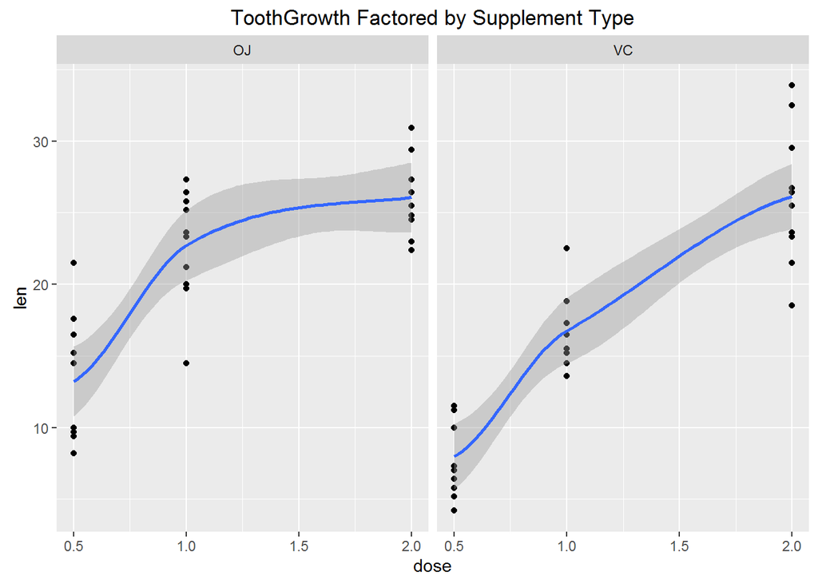

#### Use confidence intervals and/or hypothesis tests to compare tooth growth

Perform a t-test to compare the length of the growth with the supplement.

```r
t.test(len ~ supp, paired = FALSE,  data = ToothGrowth)
```

```
##
##  Welch Two Sample t-test
##
## data:  len by supp
## t = 1.9153, df = 55.309, p-value = 0.06063
## alternative hypothesis: true difference in means is not equal to 0
## 95 percent confidence interval:
##  -0.1710156  7.5710156
## sample estimates:
## mean in group OJ mean in group VC
##         20.66333         16.96333
```

Perform a t-test to compare the length of the growth with the dose given.

```r
t.test(ToothGrowth$len , ToothGrowth$dose)
```

```
##
##  Welch Two Sample t-test
##
## data:  ToothGrowth$len and ToothGrowth$dose
## t = 17.81, df = 59.798, p-value < 2.2e-16
## alternative hypothesis: true difference in means is not equal to 0
## 95 percent confidence interval:
##  15.66453 19.62881
## sample estimates:
## mean of x mean of y
## 18.813333  1.166667
```

Perform an analysis of the variance

```r
summary(aov(len ~ supp * dose, data=ToothGrowth))
```

```
##             Df Sum Sq Mean Sq F value   Pr(>F)
## supp         1  205.4   205.4  12.317 0.000894 ***
## dose         1 2224.3  2224.3 133.415  < 2e-16 ***
## supp:dose    1   88.9    88.9   5.333 0.024631 *
## Residuals   56  933.6    16.7
## ---
## Signif. codes:  0 '***' 0.001 '**' 0.01 '*' 0.05 '.' 0.1 ' ' 1
```